# Results for VDBA Scaling Analysis

## Only Datasets With Long Data

Maybe some of the small datasets are skewing it… Exclude datasets that had less than 24 hrs worth of data.

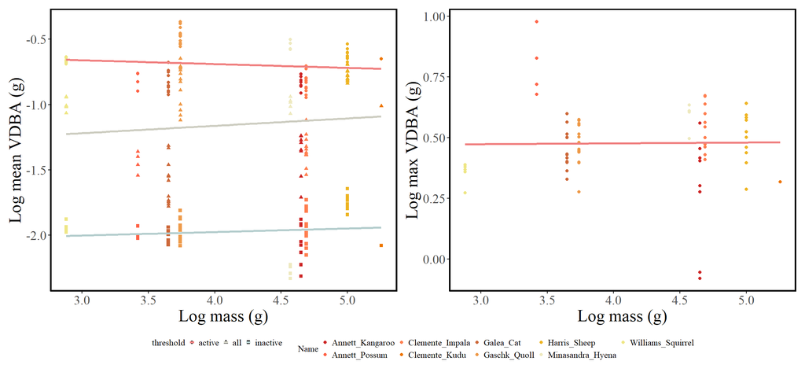

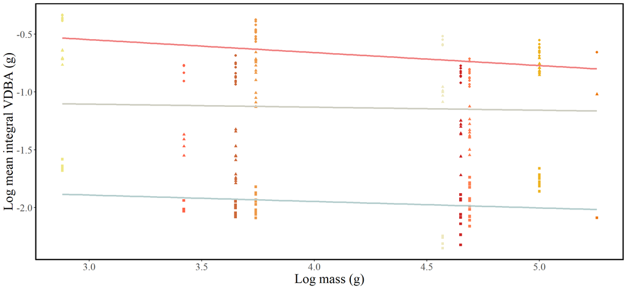

```
## # A tibble: 7 × 9
##   effect term          estimate std.error statistic    df p.value sig   variable
##   <chr>  <chr>            <dbl>     <dbl>     <dbl> <dbl>   <dbl> <chr> <chr>
## 1 fixed  LogMass       -0.0479     0.0916    -0.523 157.   0.602  not … mean
## 2 fixed  LogMass:thre…  0.197      0.105      1.88  145.   0.0628 not … mean
## 3 fixed  LogMass:thre…  0.129      0.105      1.23  145.   0.222  not … mean
## 4 fixed  LogMass        0.00769    0.0627     0.123  71.0  0.903  not … max
## 5 fixed  LogMass       -0.222      0.102     -2.18  137.   0.0310 sig   int
## 6 fixed  LogMass:thre…  0.198      0.106      1.86  145.   0.0655 not … int
## 7 fixed  LogMass:thre…  0.130      0.106      1.22  145.   0.223  not … int
```

## Collar Data Only

And then only the sepcies that were on a collar.

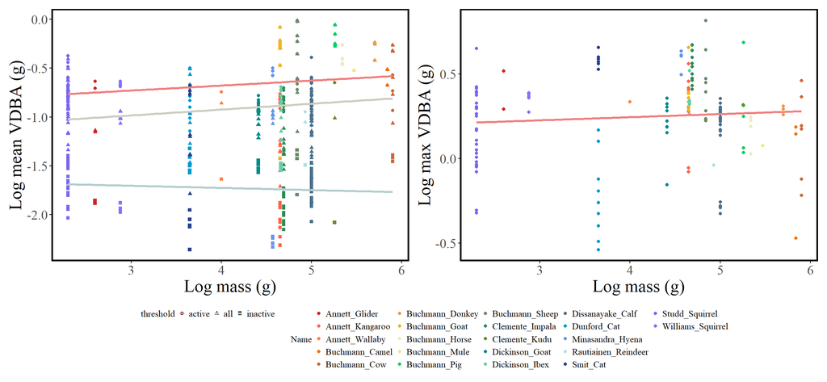

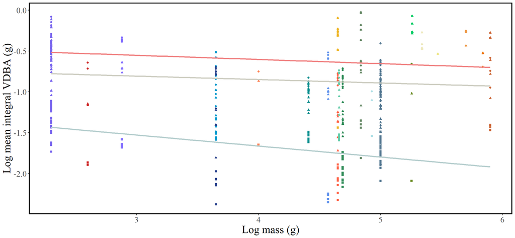

```
## # A tibble: 7 × 9
##   effect term          estimate std.error statistic    df p.value sig   variable
##   <chr>  <chr>            <dbl>     <dbl>     <dbl> <dbl>   <dbl> <chr> <chr>
## 1 fixed  LogMass        0.125      0.0510    2.46    238.  0.0147 sig   mean
## 2 fixed  LogMass:thre…  0.0209     0.0421    0.496   286.  0.620  not … mean
## 3 fixed  LogMass:thre…  0.00239    0.0459    0.0520  293.  0.959  not … mean
## 4 fixed  LogMass        0.0425     0.0421    1.01    162.  0.315  not … max
## 5 fixed  LogMass       -0.107      0.0549   -1.96    225.  0.0518 not … int
## 6 fixed  LogMass:thre…  0.0210     0.0421    0.498   288.  0.619  not … int
## 7 fixed  LogMass:thre…  0.00918    0.0460    0.200   294.  0.842  not … int
```

## Single system analysis

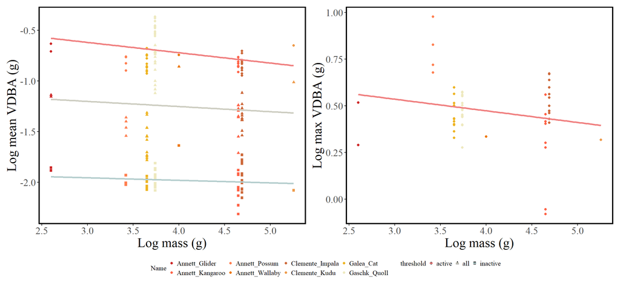

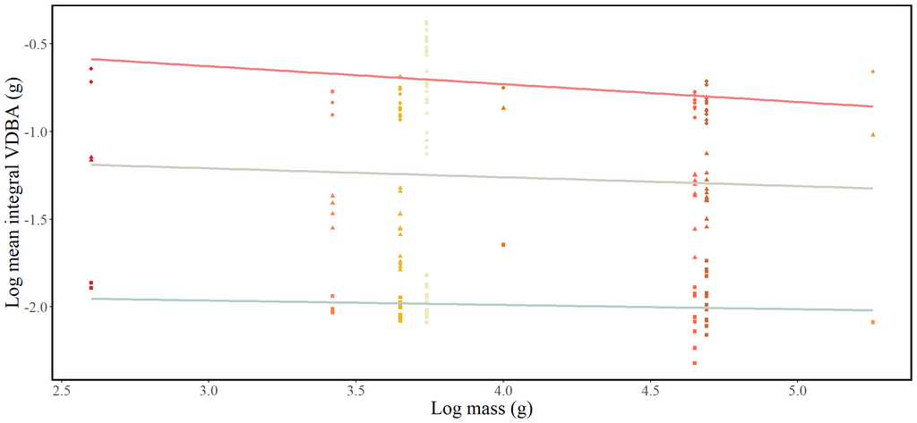

```
## # A tibble: 4 × 7
##   term                      estimate std.error statistic p.value sig    variable
##   <chr>                        <dbl>     <dbl>     <dbl>   <dbl> <chr>  <chr>
## 1 LogMass                     -0.235    0.116     -2.02   0.0450 sig    mean
## 2 LogMass:thresholdall         0.118    0.164      0.720  0.473  not s… mean
## 3 LogMass:thresholdinactive    0.178    0.164      1.08   0.281  not s… mean
## 4 LogMass                     -0.143    0.0904    -1.59   0.119  not s… max
```

# V2: Buchmann

Similarly ID was not a random effect here as too few individuals.

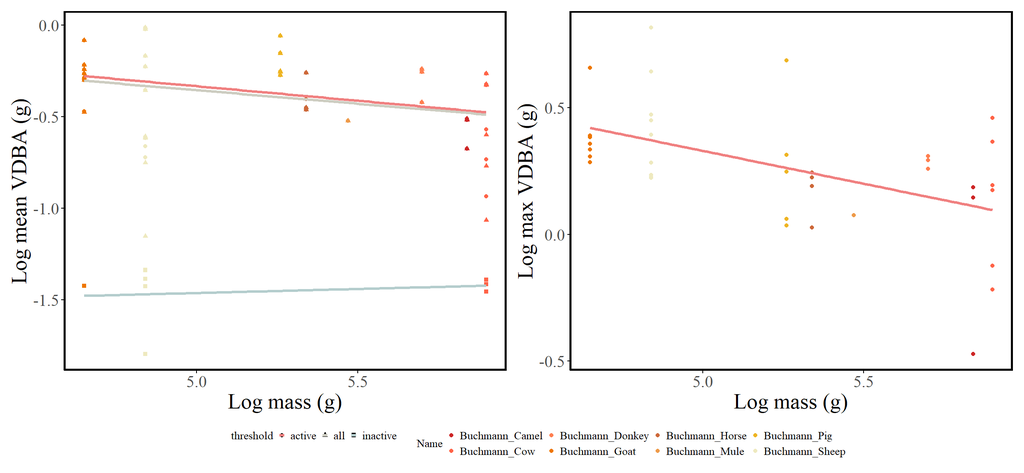

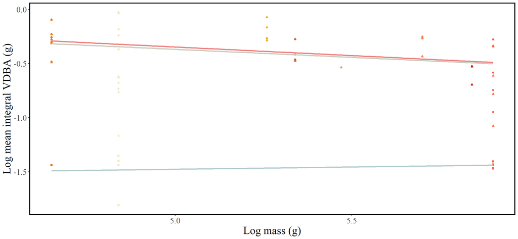

```
## # A tibble: 4 × 7
##   term                      estimate std.error statistic p.value sig    variable
##   <chr>                        <dbl>     <dbl>     <dbl>   <dbl> <chr>  <chr>
## 1 LogMass                    -0.364      0.178   -2.05   0.0442  sig    mean
## 2 LogMass:thresholdall        0.0241     0.252    0.0957 0.924   not s… mean
## 3 LogMass:thresholdinactive   0.466      0.383    1.22   0.227   not s… mean
## 4 LogMass                    -0.597      0.167   -3.57   0.00102 sig    max
```

# Pooled

Maybe the species masses are too vauge… what if we only use the datasets where we know the exact mass? Again, just a linear model with no random effect for ID.

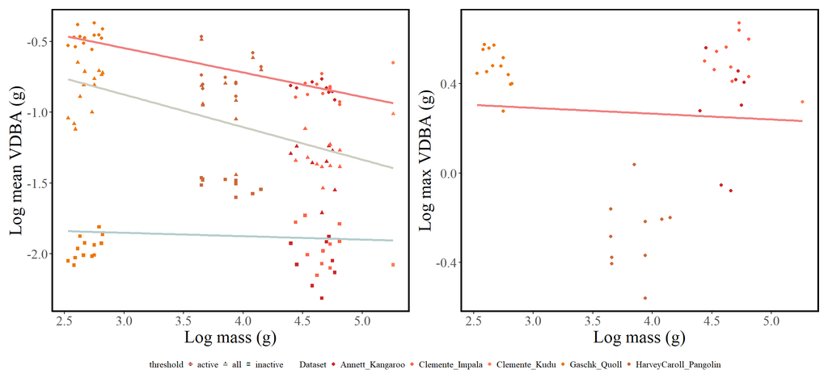

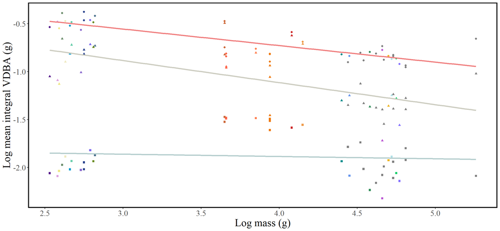

```
## # A tibble: 4 × 7
##   term                      estimate std.error statistic  p.value sig   variable
##   <chr>                        <dbl>     <dbl>     <dbl>    <dbl> <chr> <chr>
## 1 LogMass                    -0.397     0.0806    -4.93   2.69e-6 sig   mean
## 2 LogMass:thresholdall       -0.132     0.114     -1.16   2.47e-1 not … mean
## 3 LogMass:thresholdinactive   0.342     0.114      3.00   3.29e-3 sig   mean
## 4 LogMass                    -0.0597    0.144     -0.415  6.80e-1 not … max
```

# Even further separated

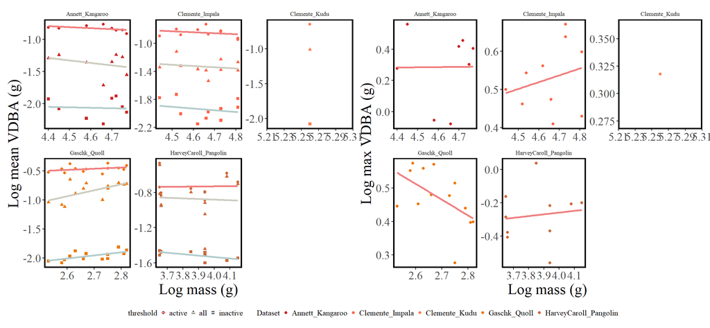

## Understanding the animal activity

# Find the active minutes per day

Is there a mass-mediated effect on activity patterns generally

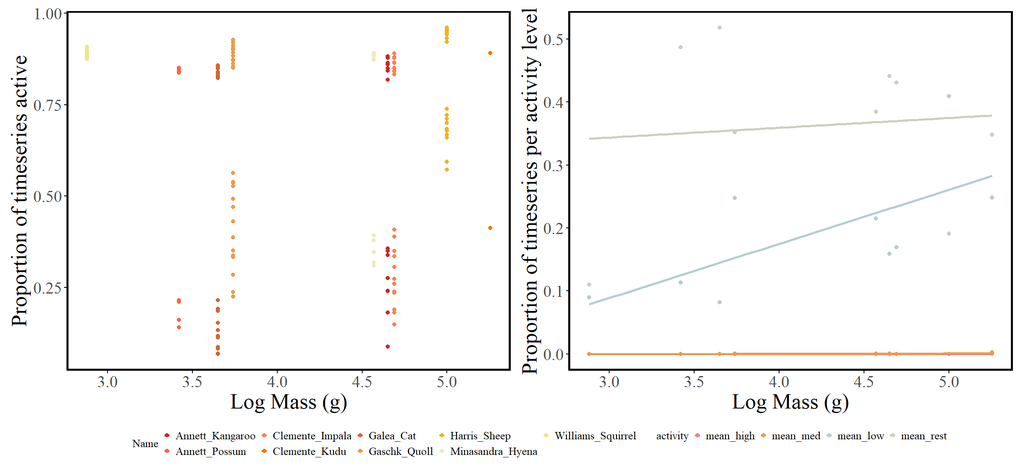